# California Spiny Lobster Abundance and Carapace Size - Assignment 4

Vanessa Rathbone and Nicole Schmidt

11/18/2019

##### INTRODUCTION

Spiny Lobster (Panulirus interruptus) are a species of special interest in California because they are a key predator in giant kelp forests. Kelp forests provide an abundance of food and coastline protection to shoreline communities. In 2012, two marine protected areas (MPAs) were established in Santa Barbara County at Naples and Isla Vista. The Santa Barbara Coastal Long Term Ecological Research Team (SBC LTER) began collecting samples at five different kelp forest research sites. Two of these sites are within MPAs (Naples and Isla Vista) and three are outside of the MPA zones (Arroyo Quemodo, Mohawk, and Carpinteria). In this report, we explore data from the SBC LTR team to analyze changes in lobster population trends, abundance, and size at MPA sites versus non-MPA sites in 2012 and 2018.

[figure not shown]

**Figure 1.** *California spiny lobster (Panulirus interruptus). Credit: [Golden State Images](http://www.goldenstateimages.com/GSI_big.php?img=LOB-005).*

[figure not shown]

**Figure 2.** *Spacial Coverage of the five data sites. Credit: [Santa Barbara Coastal LTER, Danial C. Reed](https://portal.edirepository.org/nis/mapbrowse?scope=knb-lter-sbc&identifier=77&revision=newest)*

##### DATA AND METHODS

The dataset includes abundance (count) and carapace size (mm) data of spiny lobster in the 5 designated sites in Santa Barbara County between 2012 and 2018. The data is collected annually by divers from October to March before the start of the lobster season. During that time, data is collected every 2-4 weeks. Our methods for observing and analyzing the data include visually exploring the data and conducting the following statistical tests: two-sided T-tests ($\alpha$ = 0.05 throughout), mean, standard deviation, sample size, confidence intervals, p-value, and effect size. Specifically, we used these tests to infer distributions and differences across these key variables: size, count, years and sites. Analysis and figures were prepared using R software version 3.6.1.

##### RESULTS A: Abundance of lobsters per site

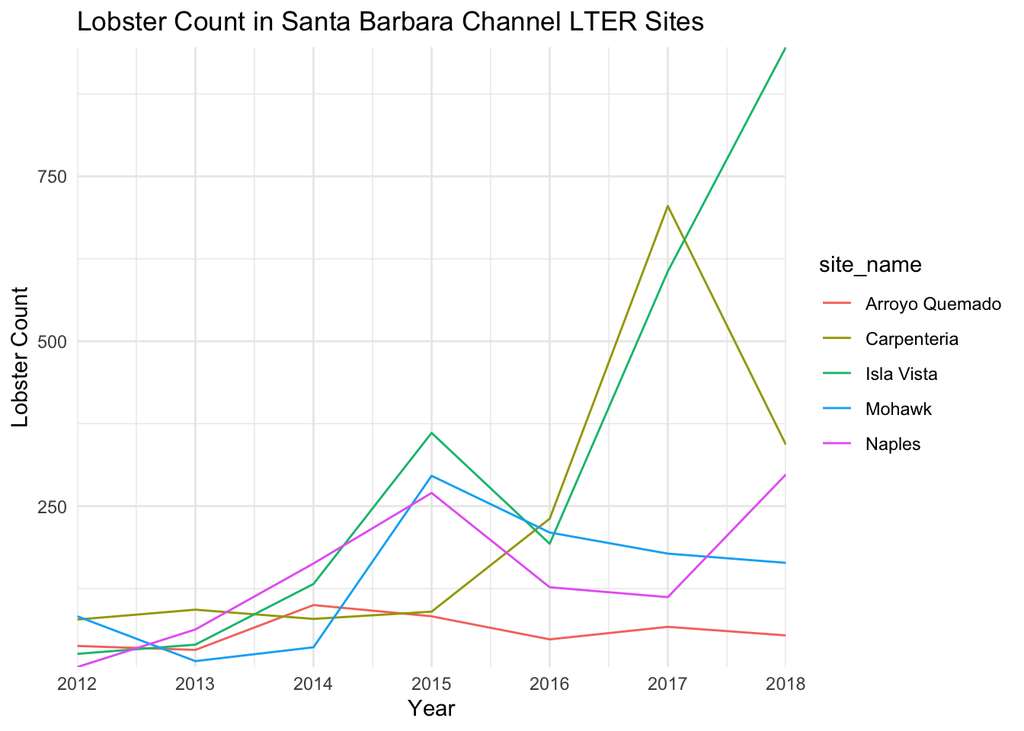

##### RESULTS B: Lobster size distribution shifts in 2012 and 2018

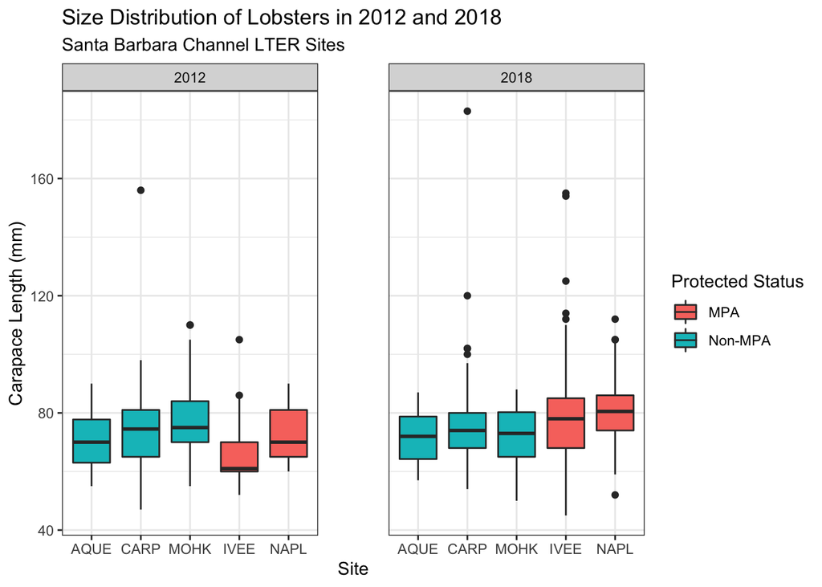

**Figure 4.** *Size distribution shifts of lobsters at all five sites at years 2012 and 2018 comparing changes in MPA versus non-MPA sites. The average size of lobster carapices (mm) increased for both MPA sites (IVEE and NAPL), while the non-MPA sites average carpace sizes remained similar between the years.*

##### RESULTS C: Compare mean lobster sizes (mm) at marine protected areas (MPAs) vs. non-marine protected areas (non-MPAs) in 2012 and 2018

**Table 1.** *Lobster mean carapace size (mm) significanly increased for MPA sites from 2012 to 2018, while mean carapace size (mm) decreased at non-MPA sites. Sample sizes increased from 231 in 2012 to 1805 in 2018.*

| Spiny Lobster Size (mm) Data Year | Spiny Lobster Size (mm) Data MPA | Spiny Lobster Size (mm) Data Mean (mm) | Spiny Lobster Size (mm) Data Standard Deviation (mm) | Spiny Lobster Size (mm) Data Sample Size |
| --- | --- | --- | --- | --- |
| 2012 | MPA | 67.38 | 12.15 | 32 |
| 2012 | non-MPA | 74.92 | 12.41 | 199 |
| 2018 | MPA | 77.57 | 11.70 | 1244 |
| 2018 | non-MPA | 73.62 | 10.09 | 561 |

For MPA sites, between 2012 and 2018, the mean carapice size (mm) of lobsters increased by 10.2 millimeters (from 67.4 to 77.6). This size increase is statistically significant as seen in the two-sided, unpaired t-test, (t(32.5)) = -4.7, *p* = 0)). The effect size seen in the Cohen’s d test is large (-0.87) indicating that from 2012 to 2018, the mean lobster carapice size increase at MPA sites is significant and substantive.

##### REFERENCES

Reed D. 2019. *SBC LTER: Reef: Abundance, size and fishing effort for California Spiny Lobster (Panulirus interruptus), ongoing since 2012.* Environmental Data Initiative. https://doi.org/10.6073/pasta/a593a675d644fdefb736750b291579a0. Accessed 10/30/2019.

Marine Science Institute, UCSB (MSI). 2019.*[Santa Barbara Coastal LTER.]* https://sbclter.msi.ucsb.edu/. Accessed 10/30/2019.